# R como SIG

Julián Equihua

28 de enero de 2016

## Introducción

El análisis espacial y espacio-temporal es una extensión natural a las capacidades de R. Existen múltiples paquetes para manipular y analizar datos espacio-temporales en R. En esta clase vamos a dar una introducción a esto.

## matrices y data frames

Recordando, una matriz es un arreglo bidimensional con una cierta cantidad de renglones y de columnas, por ejemplo un cuadrado de $3*3$ que contenga los números del 1 al 9

```r
matriz <- matrix(seq(1,9),nrow=3,ncol=3)

matriz
```

```
##      [,1] [,2] [,3]
## [1,]    1    4    7
## [2,]    2    5    8
## [3,]    3    6    9
```

Un data.frame es también un arreglo con la diferencia de que puede contener más de un tipo de datos. Esto es, puede alojar texto, números y valores booleanos simultáneamente.

```r
numeros <- c(1,2,3)

texto <- c("hola","como","estas")

booleanos <- c(TRUE,FALSE,TRUE)

data_frame <- data.frame(numeros,texto,booleanos)

data_frame
```

```
##   numeros texto booleanos
## 1       1  hola      TRUE
## 2       2  como     FALSE
## 3       3 estas      TRUE
```

Ambos tienen asociadas coordenadas de la forma $(renglón,columna)$ que comienzan de arriba a abajo y de izquierda a derecha. Estas permiten recuperar los valores que guardan, por ejemplo la entrada $(renglón,columna)=(2,1)$ para la matriz y el data.frame que definimos antes corresponden a:

```r
matriz[2,1]
```

```
## [1] 2
```

```r
data_frame[2,1]
```

```
## [1] 2
```

También se pueden hacer búsquedas condicionales sobre estos objetos, esto es escribir en código peticiones como: dime qué valores de la primera columna de la matriz son mayores a 1.

Cuando se deja vacía una dimensión, R entiende que le estás pidiendo que incluya todos los valores existentes en ella. Por tanto, la pregunta ¿qué valores de la columna 1 de la matriz son mayores a 1? se expresa de la siguiente manera:

```r
condicion <- matriz[,1]>1

condicion
```

```
## [1] FALSE  TRUE  TRUE
```

La primer columna está compuesta por los valores 1 (que claramente no es mayor a 1), 2 y 3 por lo tanto el resultado es FALSE, TRUE, TRUE.

La misma manera de hacerle “preguntas” a una matriz se puede lograr con un data.frame

```r
condicion <- data_frame[,1]>1

condicion
```

```
## [1] FALSE  TRUE  TRUE
```

Algunas preguntas, por la naturaleza de los datos no tienen sentido. Por ejemplo de las palabras “hola”, “como”, “estas” ¿cuáles son mayores a 1?

## Rasters, primeros pasos

Un raster es simplemente una matriz de números qué tiene la intención de usarse como base para generar imágenes. A estos se les puede asociar una estructura espacial.

En R, existe el paquete “raster” que está ampliamente desarrollado y se recomienda como espina dorsal para cualquier análisis que incorpore imágenes de satélite.

La mayoría de las imágenes de satélite se pueden cargar usando la función raster(). Esta misma permite insertar una matriz en un objeto raster de R.

```r
library("raster")
matriz_raster <- raster(matriz)

matriz_raster
```

```
## class       : RasterLayer
## dimensions  : 3, 3, 9  (nrow, ncol, ncell)
## resolution  : 0.3333333, 0.3333333  (x, y)
## extent      : 0, 1, 0, 1  (xmin, xmax, ymin, ymax)
## coord. ref. : NA
## data source : in memory
## names       : layer
## values      : 1, 9  (min, max)
```

Como podrá notarse, el objeto matriz_raster es ya un raster. Si bien, uno poco interesante y sin proyección.

Se mencionó que los rasters están pensados para ser la base de imágenes. El paquete “raster” contiene funcionalidades básicas de visualización de objetos raster.

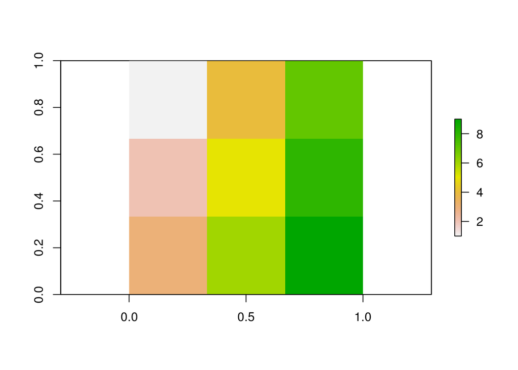

```r
plot(matriz_raster)
```

Es muy importante observar que un objeto raster tiene asociados dos conjuntos de coordenadas. El objeto matriz_raster anterior se generó a partir de una matriz de dimensión $3*3$ por lo que está conformado por 9 píxeles que se ubican a través de su (renglón,columna). Por otro lado, define un espacio abstracto continuo localizado en el extent: 0, 1, 0, 1 (xmin, xmax, ymin, ymax). Por tanto la resolución (tamaño de cada píxel) del raster es de $0.333*0.333$.

En este contexto, los puntos son objetos espaciales sin área. Por lo que uno se puede localizar en cualquier lugar del espacio que definimos, por ejemplo en las coordenadas $(0.25,0.75)$

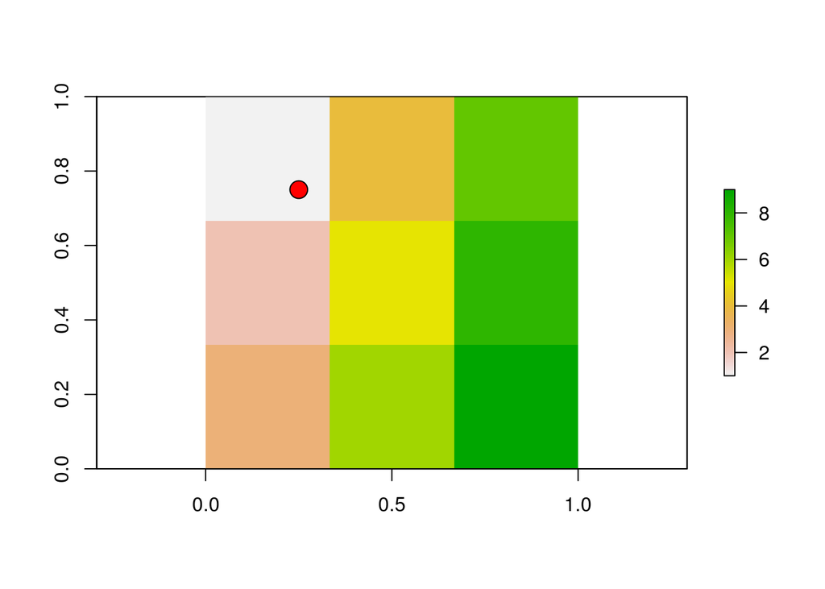

```r
plot(matriz_raster)

points(0.25,0.75,pch=21,bg="red",cex=2)
```

Utilizando el paquete “rasterVis” que es uno cuya intención primordial es visualizar rasters y sus análisis podemos visualizar este raster muy simple con los valores correspondientes a cada pixel. Esto permitirá observar el resultado de los siguientes procesos que llevaremos a cabo.

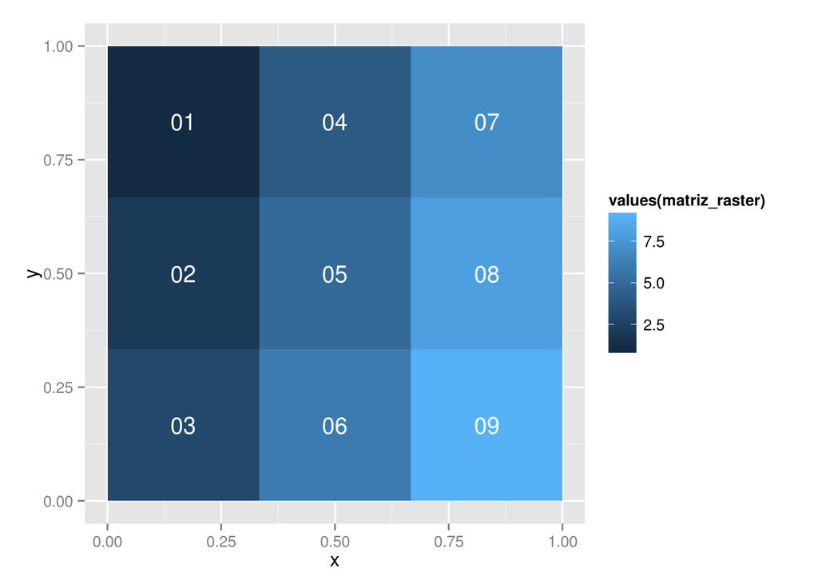

```r
library("ggplot2")
library("rasterVis")
gplot(matriz_raster) + geom_tile(aes(fill=values(matriz_raster))) +
                  scale_colour_brewer(palette="Blues")  +
                  coord_equal() +
                  geom_text(aes(label=sprintf("%02.0f",values(matriz_raster))),color="white",size=5)
```

Análogamente a como sucedía con la matriz, podemos recuperar el valor del raster en la entrada $(renglón,columna)=(2,1)$

```r
matriz_raster[2,1]
```

```
##
## 2
```

Un raster también es entendido en R como un vector de arriba a abajo y de izquierda a derecha. En este caso el arreglo tiene longitud 9 y la entrada $(renglón,columna)=(2,1)$ es igual a la entrada $[4]$.

```r
matriz_raster[4]
```

```
##
## 2
```

Lo anterior en combinación con expresiones condicionales nos permite hacer búsquedas y manipular rasters.

Podemos multiplicar el raster en su totalidad por 2 y restarle la constante 1.

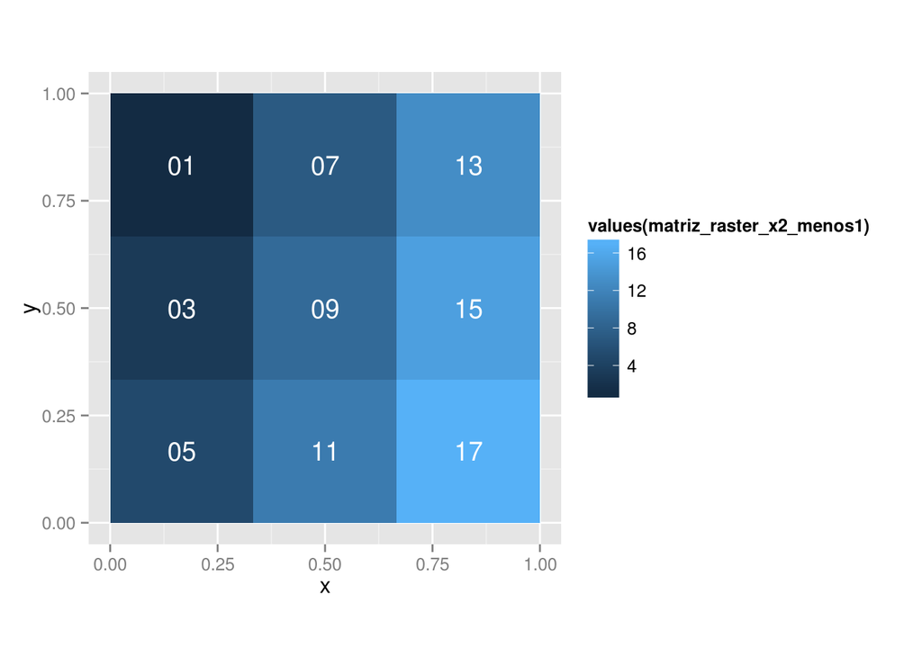

```r
matriz_raster_x2_menos1 <- matriz_raster * 2 - 1

gplot(matriz_raster_x2_menos1) + geom_tile(aes(fill=values(matriz_raster_x2_menos1))) +
                  scale_colour_brewer(palette="Blues")  +
                  coord_equal() +
                  geom_text(aes(label=sprintf("%02.0f",values(matriz_raster_x2_menos1))),color="white",size=5)
```

Podemos reemplazar todos los píxeles del raster que cumplan la condición de ser mayores a 4 por 999. Esto se logra expresando la condición de manera análoga a como lo hicimos para matrices. Como un raster se puede ver como un vector, basta con meter la condición en una única dimensión

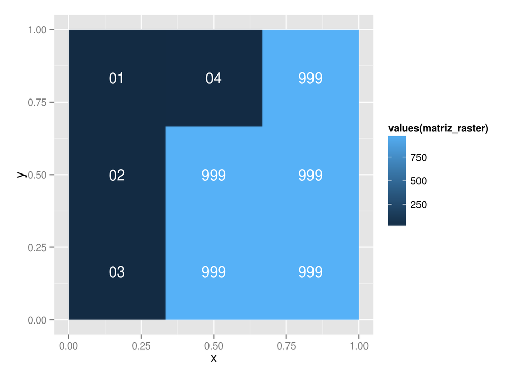

```r
# reemplazar matriz_raster donde matriz_raster mayor a 4 por 999
 matriz_raster[matriz_raster>4] <- 999

gplot(matriz_raster) + geom_tile(aes(fill=values(matriz_raster))) +
                  scale_colour_brewer(palette="Blues")  +
                  coord_equal() +
                  geom_text(aes(label=sprintf("%02.0f",values(matriz_raster))),color="white",size=5)
```

Hay funciones básicas en el paquete raster que son útiles en mútiples situaciones:

cellStats() calcula un estadístico definido por el usuario sobre un raster de entrada, por ejemplo se puede usar para obtener el promedio de un raster

```r
cellStats(matriz_raster,stat="mean")
```

```
## [1] 556.1111
```